# Some Results from the UNOS Data

Fan Wu

2016-11-09

## Data Manipulation

We use the ESRD patients listed in 2006 from 41 U.S. states. The follow-up was untill Dec. 4, 2015. The time origin is set at the ESRD onset, which is the *date of the first regulatory dialysis*. The event of interest is patient death. We exclude those

- without a dialysis date
- put on the waiting list with out reaching ESRD (defined by starting dialysis)
- have unknow dialysis modality before listed

We allow the renal replacement therapy of a patient change during the follow up, from dialysis to TX after receiving an allograft, or from TX to dialysis following the allograft failure and he/her is on dialysis again. Thus, the treatment is treated as a **time-dependent** covariate.

We also adjusted for age at ESRD onset, gender and race.

The number of events for each included states are as follows:

```
##  AL  AR  AZ  CA  CO  CT  DC  FL  GA  HI  IA  IL  IN  KY  LA  MA  MD  ME
## 211  50 114 852 100  31  70 315 145  14  38 324  90  62 103 148 115  22
##  MI  MN  MO  MS  NC  ND  NE  NJ  NM  NV  NY  OH  OK  OR  PA  SC  TN  TX
## 273 113 117  15 160  16  34 162  24  25 479 229  54  56 437  36 170 496
##  UT  VA  WA  WI  WV
##  21 258  71  97  27
```

## Estimate of the PD and TX log Hazards

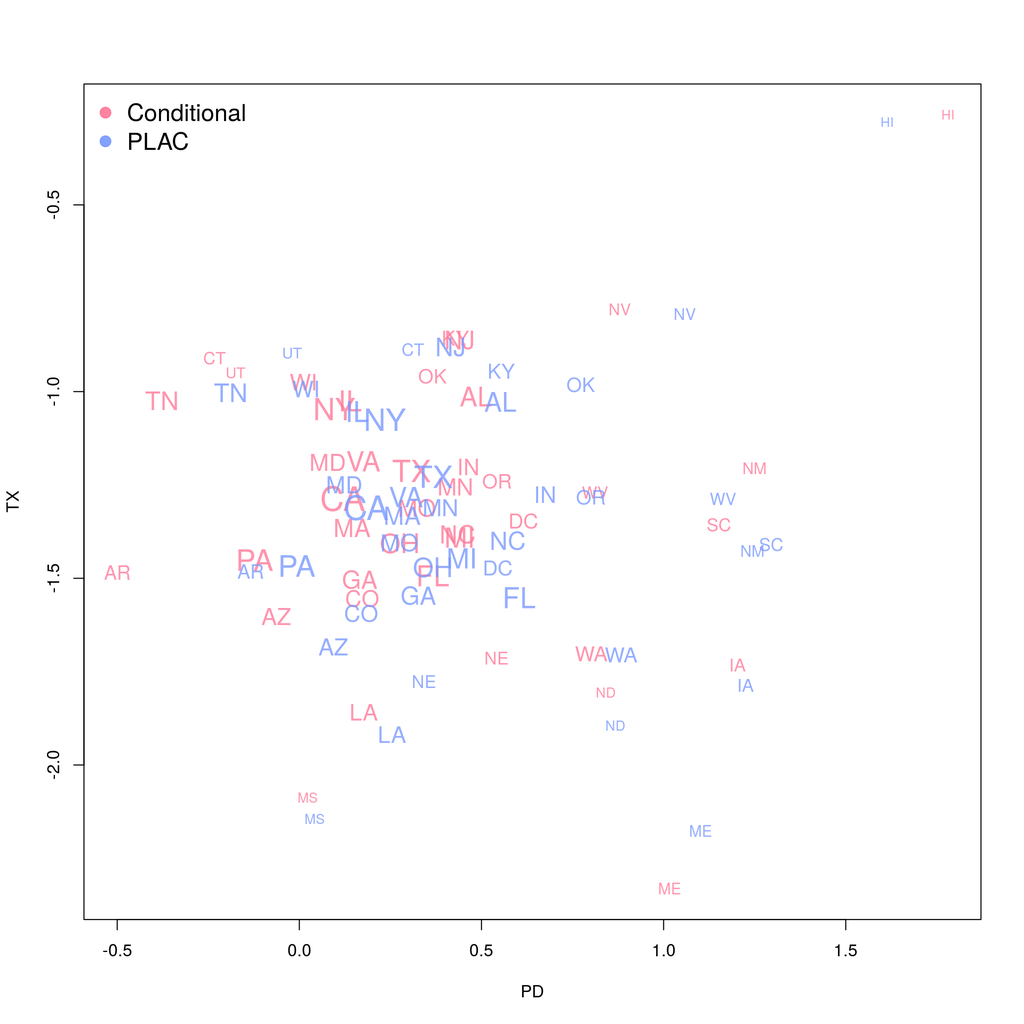

## Compare SEs using Conditional vs PLAC

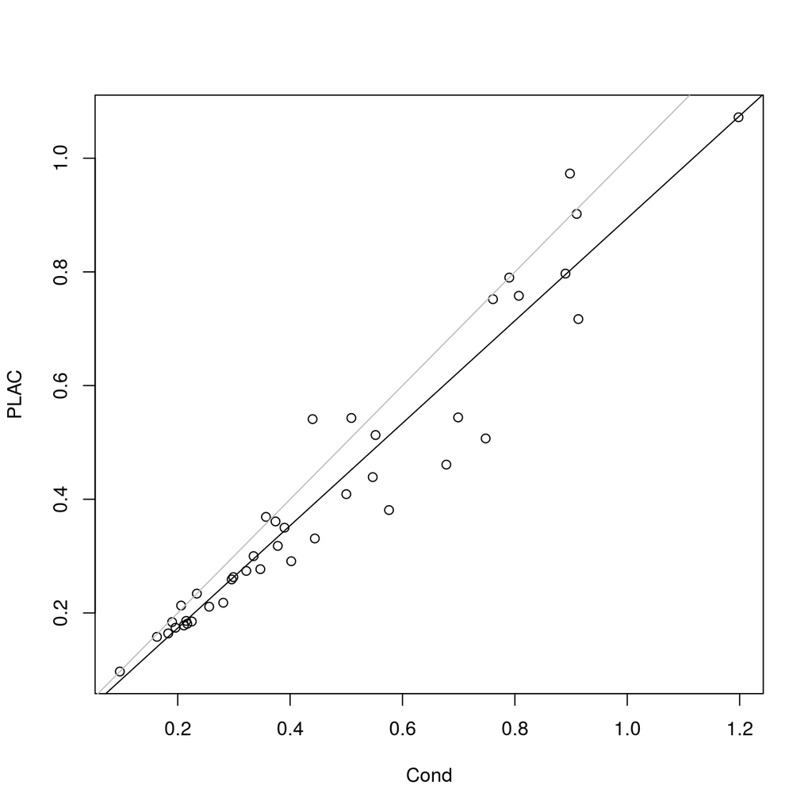

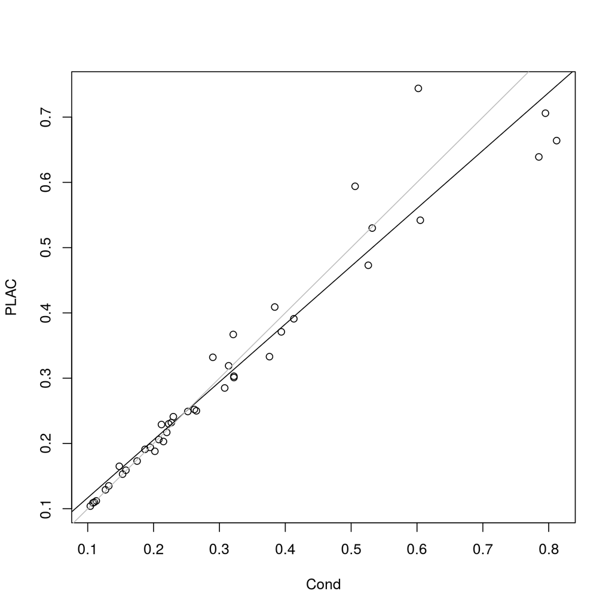

## Christmas Trees

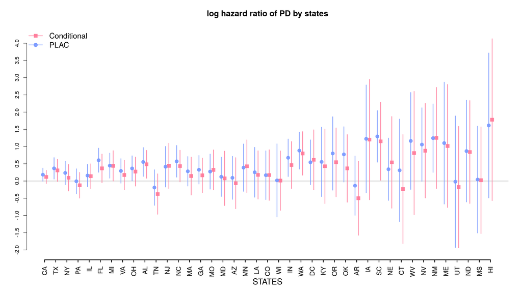

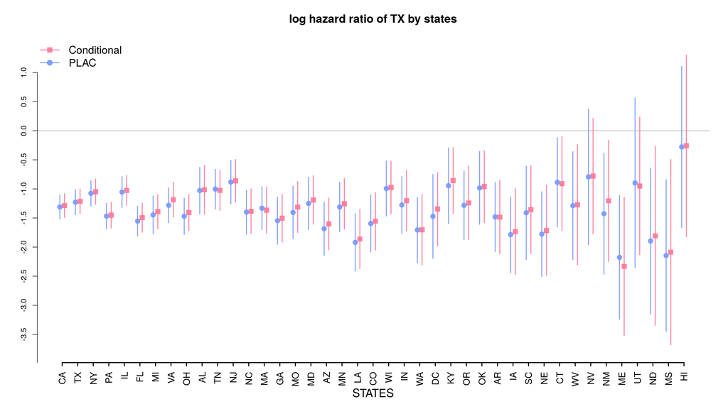

## To Make the Analysis Great Again

I may

- Include the cohort of the ESRD patient to adjusted for possible cohort effect
- Categorize the continuous AGE0 variable to <45, 45-64, 65+ to allow for non-linear age effect
- Change the time point of switching the “on-going” treatment (e.g., 60 days after the switch)